# hetoolkit-Vignette

APEM Ltd

# Installation

```r
if (!require(pacman)) install.packages("pacman")
pacman::p_load(dplyr, insight, lubridate, readr, downloader, readxl, RCurl, writexl, tidyr, stringr,
    tibble, htmlTable, devtools, roxygen2, plotly, ggnewscale, ggplot2, fasstr, lme4, sjmisc, mgcv,
    gridExtra, ggfortify, plyr, visreg, formatR, sf, ggrepel, reshape, grid, glmmTMB, remotes, merTools,
    GGally, plyr, imputeTS)

# for development install.packages('devtools')
library(devtools)
devtools::load_all(export_all = FALSE)
# install_deps() for public version (once live) remotes::install_github('APEM-LTD/hetoolkit')
# library(hetoolkit)
```

# Introduction

- `import_nrfa` for importing flow data from the National River Flow Archive (NRFA);
- `import_hde` for importing flow data from the Environment Agency (EA) Hydrology Data Explorer (HDE);
- `import_flowfiles` for importing flow data from local files;
- `import_flow` for importing flow data from a mix of the above sources;
- `impute_flow` for infilling missing records in daily flow time series for one or more sites (gauging stations) using either an interpolation or an equipercentile method.
- `import_inv` for importing macroinvertebrate sampling data from the EA Ecology and Fish Data Explorer;
- `import_env` for importing environmental base data from the EA Ecology and Fish Data Explorer;
- `import_rhs` for importing River Habitat Survey (RHS) data from the EA’s Open Data portal;
- `predict_indices` for calculating expected scores for macroinvertebrate indices using the RICT model (FBA 2020);
- `calc_flowstats` and `calc_rfrstats` for calculating summary statistics describing historical flow conditions;
- `join_he` for joining the above datasets;
- `plot_heatmap` for visualising and summarising gaps in time series data;
- `plot_hev` and `shiny_hev` for producing time series plots of biology and flow data;
- `plot_sitepca` for summarising environmental characteristics of biological sampling sites;
- `plot_rngflows` for Visualising the range of flow conditions experienced historically at a site;
- `model_cv` and `model_logocv` for performing cross-validation on linear mixed-effects models and hierarchical generalized additive models;
- `diag_lmer` for generating a variety of diagnostic plots for a mixed-effects regression (lmer) model; and
- `plot_predictions` for visualising the time series predictions from a hydro-ecological model.

This vignette illustrates a typical workflow using a selection of 20 macroinvertebrate sampling sites from the Environment Agency’s National Drought Monitoring Network (NDMN).

Although the package has been developed with macroinvertebrate data in mind, the functions can be used with any kind of biological sampling data.

# Meta-data file

To link together disparate datasets requires a look-up table of site ids. In this example, we load a table with four columns:

- *biol_site_id* = id of biology (in this case macroinvertebrate) sampling site.
- *flow_site_id* = id of paired flow gauging station.
- *flow_input* = vector specifying where to source the flow data for station (either National River Flow Archive “NRFA”, Hydrology Data Explorer “HDE”, or local files “FLOWFILES”).
- *rhs_survey_id* = id of paired River Habitat Survey (RHS) (survey id, not not site id, in case multiple surveys have been undertaken at a site).

```r
# load master file
data("master_file")

# make all columns character vectors
master_file$biol_site_id <- as.character(master_file$biol_site_id)
master_file$rhs_survey_id <- as.character(master_file$rhs_survey_id)

# filter master file for selected sites of interest
master_data <- master_file %>%
    filter(biol_site_id %in% c("34310", "34343", "34352", "55287", "55395", "55417", "55673", "55824",
        "55897", "56065", "56226", "54637", "54769", "54801", "54962", "80998", "56491", "54827",
        "77216", "52828"))

# view data
master_data
```

```
## # A tibble: 20 x 4
##    biol_site_id flow_site_id flow_input rhs_survey_id
##    <chr>        <chr>        <chr>      <chr>
##  1 34310        2859TH       HDE        39880
##  2 34343        4790TH       HDE        39881
##  3 34352        5420TH       HDE        39797
##  4 77216        F3105        HDE        39621
##  5 52828        4175         HDE        39804
##  6 55287        029003       HDE        38660
##  7 55395        029001       HDE        38669
##  8 55417        030017       HDE        38670
##  9 55673        032806       HDE        39205
## 10 55824        031031       HDE        39707
## 11 55897        033044       HDE        39798
## 12 56065        033051       HDE        39310
## 13 56226        033022       HDE        39839
## 14 54637        037005       HDE        39560
## 15 54769        035004       HDE        38952
## 16 54801        034003       HDE        39612
## 17 54962        034014       HDE        39611
## 18 80998        034206       HDE        39891
## 19 56491        U33093       HDE        39758
## 20 54827        035002       HDE        39574
```

```r
# get site lists, for use with functions
biolsites <- master_data$biol_site_id
flowsites <- master_data$flow_site_id
flowinputs <- master_data$flow_input
rhssurveys <- master_data$rhs_survey_id
```

## Standardised Column Names

A number of standardised column names are used throughout the `hetoolkit` package, and throughout this vignette and its associated datasets. These include:

- *biol_site_id* = macroinvertebrate sampling site ids.
- *flow_site_id* = flow gauging station ids.
- *rhs_survey_id* = River Habitat Survey (RHS) ids (survey id, not not site id, in case multiple surveys have been undertaken at a site).
- *flow* = flow data, as downloaded using the `import_flow` function

# Prepare biology, ENV and RHS data

## Import biology data

The `import_inv` function imports macroinvertebrate sampling data from the Environment Agency’s Ecology and Fish Data Explorer. The data can either be downloaded from https://environment.data.gov.uk/ecology-fish/downloads/INV_OPEN_DATA.zip or read in from a local .csv or .rds file. The data can be optionally filtered by site ID and sample date.

Below, we use our list `biolsites` to filter the data from EDE.

```r
# Import biology data from EDE
biol_data <- import_inv(sites = biolsites, start_date = "2010-01-01", end_date = "2020-12-31")
```

```r
# view biol_data
biol_data
```

```
## # A tibble: 533 x 58
##    biol_site_id SAMPLE_ID SAMPLE_VERSION REPLICATE_CODE SAMPLE_DATE SAMPLE_TYPE SAMPLE_TYPE_DES~
##    <chr>        <chr>              <int> <chr>          <date>      <fct>       <fct>
##  1 56065        605567                 1 <NA>           2010-03-16  SP          FRESHWATER: INV~
##  2 56065        611126                 1 <NA>           2010-07-28  SP          FRESHWATER: INV~
##  3 56065        614704                 1 <NA>           2010-10-12  SP          FRESHWATER: INV~
##  4 56065        621146                 1 <NA>           2011-03-29  SP          FRESHWATER: INV~
##  5 56065        625474                 1 <NA>           2011-06-14  SP          FRESHWATER: INV~
##  6 56065        627625                 1 <NA>           2011-08-06  SP          FRESHWATER: INV~
##  7 56065        630894                 1 <NA>           2011-10-12  SP          FRESHWATER: INV~
##  8 56065        633498                 1 <NA>           2011-12-09  SP          FRESHWATER: INV~
##  9 56065        634677                 1 <NA>           2012-02-08  SP          FRESHWATER: INV~
## 10 56065        635806                 1 <NA>           2012-04-12  SP          FRESHWATER: INV~
## # ... with 523 more rows, and 51 more variables: SAMPLE_METHOD <fct>,
## #   SAMPLE_METHOD_DESCRIPTION <fct>, SAMPLE_REASON <fct>, ANALYSIS_ID <int>,
## #   DATE_OF_ANALYSIS <date>, ANALYSIS_TYPE <fct>, ANALYSIS_TYPE_DESCRIPTION <fct>,
## #   ANALYSIS_METHOD <fct>, ANALYSIS_METHOD_DESCRIPTION <fct>, BMWP_N_TAXA <dbl>,
## #   BMWP_TOTAL <dbl>, BMWP_ASPT <dbl>, CCI_N_TAXA <dbl>, CCI_CS_TOTAL <dbl>, CCI_ASPT <dbl>,
## #   CSmax_CoS <dbl>, BMWP_CoS <dbl>, CCI_CoS <dbl>, CCI <dbl>, DEHLI_N_TAXA <dbl>,
## #   DIS_TOTAL <dbl>, DEHLI <dbl>, EPSI_ML_S_GRP <dbl>, EPSI_ML_ALL_GRP <dbl>, ...
```

## Optional: Join additional biology data

If the user has additional biology data in a separate Excel file, it is possible to append this to the EDE download. The additional data must have the same column names as the EDE download file.

```r
# bind 2 biology data sets - one from EDE and one local file

# drop any unwanted variables/columns from the EDE download file
drops_bio <- c("SAMPLE_VERSION", "REPLICATE_CODE", "SAMPLE_TYPE", "SAMPLE_METHOD", "ANALYSIS_TYPE",
    "ANALYSIS_METHOD", "IS_THIRD_PARTY_DATA", "WATERBODY_TYPE")

# drop unwanted variables
biol_data2 <- biol_data[, !(names(biol_data) %in% drops_bio)]

# read in additional biology data in csv format
biol_data_excel <- read.csv("data/biol_data_join.csv")

# format columns
biol_data_excel <- biol_data_excel %>%
    dplyr::mutate(biol_site_id = as.character(biol_site_id))

# convert to tibble format
biol_data_excel <- as_tibble(biol_data_excel)

# bind datasets
biol_data_final <- rbind(biol_data2, biol_data_excel)
```

## Import environmental data

The `import_env` function allows the user to download environmental base data from the Environment Agency’s Ecology and Fish Data Explorer.

The function either:

- downloads environmental data data from https://environment.data.gov.uk/ecology-fish/downloads/INV_OPEN_DATA.zip
- **or** imports it from a local .csv or .rds file

Data can be optionally filtered by site ID.

When saving, the name of rds file is hard-wired to: INV_OPEN_DATA_SITES_ALL.rds.

If saving prior to filtering, the name of the filtered rds file is hard-wired to: INV_OPEN_DATA_SITE_F.rds.

Below, we use our list `biolsites` to filter the data from EDE.

```r
# Import biology data from EDE
env_data <- import_env(sites = biolsites)
```

```r
# view env_data
env_data
```

```
## # A tibble: 20 x 34
##    AGENCY_AREA  REPORTING_AREA CATCHMENT WATERBODY_TYPE WATERBODY_TYPE_~ WATER_BODY biol_site_id
##    <chr>        <chr>          <chr>     <chr>          <chr>            <chr>      <chr>
##  1 ANGLIAN - N~ LINCOLNSHIRE ~ EAST LIN~ WBRV           RIVER: Natural/~ WAITHE BE~ 55395
##  2 ANGLIAN - E~ EAST ANGLIA -~ WENSUM    WBRV           RIVER: Natural/~ WENSUM     54962
##  3 ANGLIAN - N~ LINCOLNSHIRE ~ CENTRAL ~ WBRV           RIVER: Natural/~ UPPER WIT~ 55417
##  4 THAMES - NO~ HERTFORDSHIRE~ RODING    WBRV           RIVER: Natural/~ RODING     34352
##  5 ANGLIAN - E~ EAST ANGLIA -~ COLNE (A~ WBRV           RIVER: Natural/~ COLNE      54637
##  6 ANGLIAN - N~ LINCOLNSHIRE ~ EAST LIN~ WBRV           RIVER: Natural/~ LUD        55287
##  7 ANGLIAN - E~ EAST ANGLIA -~ ALDE AND~ WBRV           RIVER: Natural/~ ALDE       54769
##  8 ANGLIAN - C~ EAST ANGLIA -~ UPPER OU~ WBRV           RIVER: Natural/~ OUSE (UPP~ 56491
##  9 THAMES - NO~ HERTFORDSHIRE~ MIMRAM    WBRV           RIVER: Natural/~ MIMRAM     34343
## 10 NORTH EAST ~ YORKSHIRE      HULL      WBRV           RIVER: Natural/~ HULL/WEST~ 77216
## 11 MIDLANDS - ~ WEST MIDLANDS  MEASE (U~ WBRV           RIVER: Natural/~ MEASE      52828
## 12 ANGLIAN - E~ EAST ANGLIA -~ BURE      WBRV           RIVER: Natural/~ BURE       54801
## 13 ANGLIAN - E~ EAST ANGLIA -~ DEBEN     WBRV           RIVER: Natural/~ DEBEN      54827
## 14 ANGLIAN - N~ LINCOLNSHIRE ~ WELLAND   WBRV           RIVER: Natural/~ WELLAND    55824
## 15 ANGLIAN - C~ EAST ANGLIA -~ IVEL      WBRV           RIVER: Natural/~ IVEL       56226
## 16 THAMES - NO~ HERTFORDSHIRE~ COLNE (T~ WBRV           RIVER: Natural/~ CHESS      34310
## 17 ANGLIAN - N~ LINCOLNSHIRE ~ UPPER NE~ WBRV           RIVER: Natural/~ NENE       55673
## 18 ANGLIAN - E~ EAST ANGLIA -~ WAVENEY ~ WBRV           RIVER: Natural/~ WAVENEY    80998
## 19 ANGLIAN - C~ EAST ANGLIA -~ CAM (2)   WBRV           RIVER: Natural/~ CAM        56065
## 20 ANGLIAN - C~ EAST ANGLIA -~ LT OUSE,~ WBRV           RIVER: Natural/~ THET       55897
## # ... with 27 more variables: SITE_VERSION <int>, NGR_PREFIX <chr>, EASTING <chr>,
## #   NORTHING <chr>, NGR_10_FIG <chr>, FULL_EASTING <int>, FULL_NORTHING <int>,
## #   WFD_WATERBODY_ID <chr>, ALTITUDE <dbl>, SLOPE <dbl>, DIST_FROM_SOURCE <dbl>,
## #   DISCHARGE <dbl>, WIDTH <dbl>, DEPTH <dbl>, BOULDERS_COBBLES <dbl>, PEBBLES_GRAVEL <dbl>,
## #   SAND <dbl>, SILT_CLAY <dbl>, ALKALINITY <dbl>, CONDUCTIVITY <dbl>, TOTAL_HARDNESS <dbl>,
## #   CALCIUM <dbl>, BASE_DATA_DATE <date>, MIN_SAMPLE_DATE <date>, MAX_SAMPLE_DATE <date>,
## #   COUNT_OF_SAMPLES <int>, ECN_SITE_INV <lgl>
```

## Optional: Map biology sites

### Get data

First we download zipped shapefiles for our basemap, and load them in as sf objects. The zipped shapefiles are left in the users project / working directory. The England map is of EA public facing area boundaries. The additional map covering the Wales coastline comes from the ESRC UK Data Service.

```r
# link not working, zip file saved in vignette folder
#download('https://environment.data.gov.uk/UserDownloads/interactive/3d91bd0c20b74#7b1bd157a32db8aa07598172/EA_AdminBoundEAandNEpublicFaceAreas_SHP_Full.zip', #destfile = 'EA_AdminBoundEAandNEpublicFaceAreas_SHP_Full.zip')

## get Wales coastline, just because map looks silly without it
download('https://borders.ukdataservice.ac.uk/ukborders/easy_download/prebuilt/shape/Wales_ol_2001.zip', destfile = 'Wales_ol_2001.zip')

## load in the shapefiles to R objects and remove seaward parts
EA.areas <- read_sf('/vsizip/EA_AdminBoundEAandNEpublicFaceAreas_SHP_Full.zip/data/Administrative_Boundaries_Environment_Agency_and_Natural_England_Public_Face_Areas.shp')
wales <- read_sf('/vsizip/Wales_ol_2001.zip')
EA.areas.land <- EA.areas %>% dplyr::filter(seaward == 'No')
```

### Data processing

We use the environmental base data that we have downloaded from the Ecology and Fish Data Explorer using `import_env`, this gives us their NGRs. We translate the NGRs to full eastings / northings and use this to turn the base data frame into a sf point object for plotting.

```r
## translate NGRs to full easting / northing
temp.eastnorths <- osg_parse(env_data$NGR_10_FIG, coord_system = "BNG") %>% as_tibble()

## make an sf point object to plot with geom_sf but retain the easting and northing column required by geom_text_repel
env_sf <- st_as_sf(bind_cols(temp.eastnorths, env_data), coords =  c("easting", "northing"), crs = 27700, remove = FALSE)
```

### Create the map

Finally we use ggplot with geom_sf() to plot the points and ggrepel::geom_text_repel() to plot the labels.

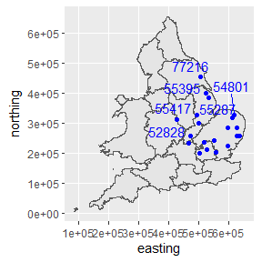

```r
basemap <- ggplot() + geom_sf(mapping = aes(), data = EA.areas.land) +
  geom_sf(mapping = aes(), data = wales)

basemap + geom_sf(data = env_sf, col = "blue", size = 1.5) +
  geom_text_repel(data = env_sf, aes(x=easting, y=northing, label = biol_site_id), col = "blue") +
  coord_sf(datum = sf::st_crs(27700))
```

## Optional: Join additional environmental data

Any additional environmental data in a separate Excel file can be appended to the EDE download. The additional data must have the same column names as the EDE download file.

```r
# bind 2 env data sets - one from EDE and one local file

# drop any unwanted variables/columns from the download file
drops_env <- c("AGENCY_AREA", "REPORTING_AREA", "CATCHMENT", "WATERBODY_TYPE", "WATERBODY_TYPE_DESCRIPTION",
    "SITE_VERSION", "NGR_10_FIG", "FULL_EASTING", "FULL_NORTHING", "BASE_DATA_DATE", "MIN_SAMPLE_DATE",
    "MAX_SAMPLE_DATE", "COUNT_OF_SAMPLES", "ECN_SITE", "INV", "ECN_SITE_INV")

# drop unwanted variables
env_data <- env_data[, !(names(env_data) %in% drops_env)]

# read-in environmental data in excel format
env_data_excel <- read_excel("data/Env_Additonal_Sites.xlsx")

# format columns
env_data_excel <- env_data_excel %>%
    dplyr::mutate(biol_site_id = as.character(biol_site_id), WATER_BODY = as.character(WATER_BODY),
        NGR_PREFIX = as.character(NGR_PREFIX), EASTING = as.character(EASTING), NORTHING = as.character(NORTHING),
        WFD_WATERBODY_ID = as.character(WFD_WATERBODY_ID))

# convert to tibble format
env_data_excel <- as_tibble(env_data_excel)

# join datasets
env_data <- rbind(env_data, env_data_excel)
```

## Import RHS data

The `import_rhs` function allows the user to download River Habitat Survey (RHS) data from Open Data.

The function either:

- downloads RHS data from Open Data, https://environment.data.gov.uk/portalstg/sharing/rest/content/items/b82d3ef3750d49f6917fff02b9341d68/data
- **or** imports it from a local xlsx or rds file.

Data can be optionally filtered by survey ID.

Downloaded raw data files (in .zip format) will be automatically removed from the working directory following completed execution of the function.

Below, we use our list `rhssurveys` to filter the downloaded data.

To enable the RHS data to be joined to the biology and flow data at a later stage, it is necessary to rename the `Survey ID` column to `rhs_survey_id`.

```r
# import RHS data from Open Data
rhs_data <- import_rhs(surveys = rhssurveys)

# rename Survey.ID as rhs_survey_id
rhs_data <- rhs_data %>%
    dplyr::rename(rhs_survey_id = Survey.ID)
```

If required, unwanted variables can be dropped from the dataset.

```r
# select Columns to keep
rhs_keep <- c("rhs_survey_id", "Hms.Poaching.Sub.Score", "Hms.Rsctned.Bnk.Bed.Sub.Score", "HMS.Score")

# select columns of interest
rhs_data <- rhs_data[, (names(rhs_data) %in% rhs_keep)]
```

```r
# view rhs_data
rhs_data
```

```
## # A tibble: 20 x 4
##    rhs_survey_id HMS.Score Hms.Poaching.Sub.Score Hms.Rsctned.Bnk.Bed.Sub.Score
##    <chr>             <dbl>                  <dbl>                         <dbl>
##  1 38660              1305                      0                            80
##  2 38669              3175                      0                          2000
##  3 38670               525                     10                             0
##  4 38952              3140                      0                          2280
##  5 39205              3420                      0                          2520
##  6 39310              3810                      0                          2200
##  7 39560               240                      0                             0
##  8 39574               780                      0                           760
##  9 39611              2480                      0                          2200
## 10 39612              2600                     50                          2000
## 11 39621               250                      0                             0
## 12 39707              3040                      0                          2720
## 13 39758              2980                      0                          2480
## 14 39797              3120                      0                          2080
## 15 39798              3570                      0                          2520
## 16 39804               340                      0                             0
## 17 39839              2855                      0                          2440
## 18 39880              1740                      0                           240
## 19 39881              1055                     60                             0
## 20 39891              3170                     10                          2760
```

## Predict expected indices

The `predict_indices` function mirrors the functionality of the RICT model available on the MS Azure platform (https://gallery.azure.ai/Experiment/RICT-package-2). Specifically, it uses the environmental data downloaded from EDE to generate expected scores under minimally impacted reference conditions for 80 indices, plus probabilities for RIVPACS end-groups. No classification is undertaken.

Data validation, transformation (conversion) and predictions are done within `predict_indices` using functionality predefined in the AquaMetrics RICT package (https://github.com/aquaMetrics/rict); specifically, the ‘rict_predict’ function from the aquaMetrics RICT package is applied.

The `predict_indices` function can accept environmental data formatted in either of two formats, specified using the ‘file_format’ argument: * “EDE” - environmental data is formatted as downloaded from the EA’s Ecology Data Explorer * “RICT” - environmental data is in the RICT template format.

To run, the following columns containing substrate composition data must not contain NAs, and must total to 100 for every site:

- BOULDERS_COBBLES
- PEBBLES_GRAVEL
- SAND
- SILT_CLAY

The code below demonstrates how to summarise whether these columns contain NAs, and how to replace NAs as required. Note, this code will only run successfully if using data in the “EDE” file format.

```r
# check substrate variables for presence of NAs
env_data %>%
    dplyr::select(BOULDERS_COBBLES, PEBBLES_GRAVEL, SAND, SILT_CLAY) %>%
    summarise_all(~sum(is.na(.)))
```

```
## # A tibble: 1 x 4
##   BOULDERS_COBBLES PEBBLES_GRAVEL  SAND SILT_CLAY
##              <int>          <int> <int>     <int>
## 1                0              0     0         0
```

```r
# replace NAs, if required
env_data$BOULDERS_COBBLES[is.na(env_data$BOULDERS_COBBLES)] <- 0
```

Now that the substrate data is complete, the expected scores can be generated. Here, we opt to calculate all available indices - we can then filter these down at a later stage.

This is an updated version of the `predict_indices` function. The first iteration of the function remains available, using `preict_indices_old`.

```r
# run predictions
predict_data <- predict_indices(env_data = env_data, file_format = "EDE", all_indices = TRUE)
```

```
##   ROW  SITE YEAR FAIL
## 1  18 80998 2022  ---
## 2   7 54769 2022  ---
##                                                                                WARNING
## 1 You provided LONGITUDE: 1.35613296461629, max value used to train model: 1.3560119.
## 2  You provided LONGITUDE: 1.4717273941385, max value used to train model: 1.3560119.
##   REPLACEMENT
## 1         ---
## 2         ---
```

```r
# view predict_data
predict_data
```

```
## # A tibble: 87 x 141
##    biol_site_id LATITUDE LONGITUDE LOG.ALTITUDE LOG.DISTANCE.FROM.SOURCE LOG.WIDTH LOG.DEPTH
##    <chr>           <dbl>     <dbl>        <dbl>                    <dbl>     <dbl>     <dbl>
##  1 55395            53.5   -0.114         1.18                     1.30      0.477      1.36
##  2 54962            52.7    1.12          1                        1.70      1.03       1.41
##  3 55417            52.8   -0.625         1.90                     1.11      0.672      1.23
##  4 34352            51.7    0.258         1.61                     1.46      0.602      1.26
##  5 54637            51.9    0.865         1                        1.59      0.845      1.19
##  6 55287            53.4   -0.0162        1.40                     0.860     0.724      1.10
##  7 54769            52.2    1.47          0.699                    1.34      0.699      1.20
##  8 56491            52.0   -1.05          1.95                     1.26      0.672      1.48
##  9 34343            51.8   -0.148         1.69                     1.26      0.954      1.42
## 10 77216            54.0   -0.379         0.699                    1.17      1.08       2.02
## # ... with 77 more rows, and 134 more variables: MEAN.SUBSTRATUM <dbl>,
## #   DISCHARGE.CATEGORY <dbl>, ALKALINITY <dbl>, LOG.ALKALINITY <dbl>, LOG.SLOPE <dbl>,
## #   MEAN.AIR.TEMP <dbl>, AIR.TEMP.RANGE <dbl>, p1 <dbl>, p2 <dbl>, p3 <dbl>, p4 <dbl>,
## #   p5 <dbl>, p6 <dbl>, p7 <dbl>, p8 <dbl>, p9 <dbl>, p10 <dbl>, p11 <dbl>, p12 <dbl>,
## #   p13 <dbl>, p14 <dbl>, p15 <dbl>, p16 <dbl>, p17 <dbl>, p18 <dbl>, p19 <dbl>, p20 <dbl>,
## #   p21 <dbl>, p22 <dbl>, p23 <dbl>, p24 <dbl>, p25 <dbl>, p26 <dbl>, p27 <dbl>, p28 <dbl>,
## #   p29 <dbl>, p30 <dbl>, p31 <dbl>, p32 <dbl>, p33 <dbl>, p34 <dbl>, p35 <dbl>, p36 <dbl>, ...
```

```r
# drop unwanted variables
keeps <- c("biol_site_id", "SEASON", "TL2_WHPT_ASPT_AbW_DistFam", "TL2_WHPT_NTAXA_AbW_DistFam", "TL3_LIFE_Fam_DistFam",
    "TL3_PSI_Fam")

predict_data <- predict_data[, (names(predict_data) %in% keeps)]

predict_data <- predict_data %>%
    dplyr::rename(Season = SEASON) %>%
    dplyr::mutate(Season = case_when(Season == 1 ~ "Spring", Season == 2 ~ "Summer", Season == 3 ~
        "Autumn"))
```

## Join Biology Data, Environmental Data, and Expected Indices

Prior to joining the biology data with other datasets, it is advisable to remove or average out any replicate or duplicate samples collected from a site within the same year and season.

```r
# average out any replicate or duplicate biology samples
biol_data <- biol_data %>%
    dplyr::group_by(biol_site_id, Year, Season) %>%
    dplyr::summarise(WHPT_ASPT = mean(WHPT_ASPT), WHPT_NTAXA = mean(WHPT_N_TAXA), PSI_F = mean(PSI_FAMILY_SCORE),
        LIFE_F = mean(LIFE_FAMILY_INDEX), date = mean(SAMPLE_DATE)) %>%
    dplyr::ungroup()
```

The following code demonstrates how to join the expected biology metric scores from `predict_indices` to the observed biology metric scores, using the common fields `biol_site_id` and `Season`.

```r
# join expected and observed biology metric scores, by biol_site_id and Season
biol_all <- dplyr::left_join(biol_data, predict_data, by = c("biol_site_id", "Season"))
```

Next the environmental base data are joined using the common field `biol_site_id`.

```r
# join ENV data, by biol_site_id
biol_all <- dplyr::left_join(biol_all, env_data, by = "biol_site_id")
```

## Calculate O/E ratios

Now that the observed and expected biology metric scores are joined into a single data frame, O:E (Observed/Expected) ratios can be calculated.

```r
# WHPT-ASPT
biol_all <- biol_all %>%
    mutate(WHPT_ASPT_O = WHPT_ASPT, WHPT_ASPT_E = TL2_WHPT_ASPT_AbW_DistFam, WHPT_ASPT_OE = WHPT_ASPT_O/WHPT_ASPT_E,
        WHPT_NTAXA_O = WHPT_NTAXA, WHPT_NTAXA_E = TL2_WHPT_NTAXA_AbW_DistFam, WHPT_NTAXA_OE = WHPT_NTAXA_O/WHPT_NTAXA_E,
        LIFE_F_O = LIFE_F, LIFE_F_E = TL3_LIFE_Fam_DistFam, LIFE_F_OE = LIFE_F_O/LIFE_F_E, PSI_O = PSI_F,
        PSI_E = TL3_PSI_Fam, PSI_OE = PSI_O/PSI_E)
```

# Prepare flow data

## View Flow Data Source

The data frame nrfa.hde provides a joined dataset which illustrates which stations we believe are available on the NRFA, and which stations are available on Hydrology Data Explorer. The dataset was created in early April 2021, and may become out of date over time.

```r
# view nrfa.hde
nrfa.hde
```

```
## # A tibble: 1,366 x 20
##    wiski.id open  Flow_Site_Name  on.nrfa on.hde  id_N name_N catchment.area_N opened_N closed_N
##    <chr>    <lgl> <chr>           <lgl>   <lgl>  <dbl> <chr>             <dbl> <chr>    <chr>
##  1 021031   FALSE Till at Etal    TRUE    FALSE  21031 Till ~            648   1956-01~ 1980-12~
##  2 021032   FALSE Glen at Kirkne~ TRUE    FALSE  21032 Glen ~            199.  1966-01~ 2010-09~
##  3 021038   TRUE  Till at Heaton~ TRUE    FALSE  21035 Till ~            656.  2002     <NA>
##  4 022001   TRUE  Coquet at Morw~ TRUE    TRUE   22001 Coque~            570.  1963-11~ <NA>
##  5 022002   FALSE Coquet at Byga~ TRUE    FALSE  22002 Coque~             59.5 1957-01~ 1980-12~
##  6 022003   TRUE  Usway Burn at ~ TRUE    TRUE   22003 Usway~             21.4 1952-01~ <NA>
##  7 022004   FALSE Aln at Hawkhill TRUE    FALSE  22004 Aln a~            205   1966-01~ 1980-12~
##  8 022006   TRUE  Blyth at Hartf~ TRUE    TRUE   22006 Blyth~            269.  1966-01~ <NA>
##  9 022007   TRUE  Wansbeck at Mi~ TRUE    TRUE   22007 Wansb~            287.  1968-01~ <NA>
## 10 <NA>     FALSE Alwin at Clenn~ TRUE    FALSE  22008 Alwin~             27.7 1969-01~ 1983-04~
## # ... with 1,356 more rows, and 10 more variables: measuring.authority.id_N <chr>,
## #   measuring.authority.station.id_N <chr>, wiskiID_H <chr>, label_H <chr>,
## #   stationReference_H <chr>, riverName_H <chr>, easting_H <dbl>, northing_H <dbl>,
## #   col_H <chr>, value_H <chr>
```

## Import flow data

`import_flow` is a high-level function that calls `import_nrfa`, `import_hde` and `import_flowfiles` to import data for a user-defined list of sites.

Below, we use the lists `flowsites` and `flowinputs` to specify sites for import.

```r
flow_data <- import_flow(sites = flowsites, inputs = flowinputs, start_date = "2010-01-01", end_date = "2019-12-31",
    dir = "data/wiski", skip_num = 21, col_order = c(1, 2, 3))
```

```r
# view flow_data
flow_data
```

```
## # A tibble: 73,040 x 5
##    input flow_site_id date        flow quality
##    <chr> <chr>        <date>     <dbl> <chr>
##  1 HDE   029001       2010-01-01 0.426 Good
##  2 HDE   029001       2010-01-02 0.418 Good
##  3 HDE   029001       2010-01-03 0.416 Good
##  4 HDE   029001       2010-01-04 0.419 Good
##  5 HDE   029001       2010-01-05 0.426 Good
##  6 HDE   029001       2010-01-06 0.422 Good
##  7 HDE   029001       2010-01-07 0.416 Good
##  8 HDE   029001       2010-01-08 0.406 Good
##  9 HDE   029001       2010-01-09 0.401 Good
## 10 HDE   029001       2010-01-10 0.54  Good
## # ... with 73,030 more rows
```

## Explore data gaps

The `plot_heatmap` function is designed to visualise and summarise gaps in time series data.

It plots time series data for multiple sites as a tiled heatmap, and optionally produces tabular summaries of data completeness by time period and site. Although designed for application with flow time series data, it can be applied to any type of numerical data, with or without a time dimension.

In the following example, `plot_heatmap` is used to explore gaps in the time series of mean daily flows, and then to summarise how complete the data is in each month.

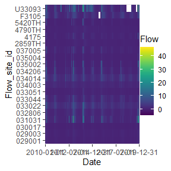

```r
# generate a heatmap of mean daily flows
a <- plot_heatmap(data = flow_data, x = "date", y = "flow_site_id", fill = "flow", dual = FALSE)
# view heatmap
gridExtra::grid.arrange(a[[1]])
```

```r
# view table of completeness statistics for each site
a[[3]]
```

```
## # A tibble: 20 x 7
##    y      missing total prop_missing number_of_gaps smallest_gap biggest_gap
##    <chr>    <int> <int>        <dbl>          <int>        <int>       <int>
##  1 029001       0  3652     0                    NA           NA          NA
##  2 029003       0  3652     0                    NA           NA          NA
##  3 030017       0  3652     0                    NA           NA          NA
##  4 031031       4  3652     0.00110               2            1           3
##  5 032806       1  3652     0.000274              1            1           1
##  6 033022       0  3652     0                    NA           NA          NA
##  7 033044       0  3652     0                    NA           NA          NA
##  8 033051       0  3652     0                    NA           NA          NA
##  9 034003       0  3652     0                    NA           NA          NA
## 10 034014       0  3652     0                    NA           NA          NA
## 11 034206       0  3652     0                    NA           NA          NA
## 12 035002       0  3652     0                    NA           NA          NA
## 13 035004       0  3652     0                    NA           NA          NA
## 14 037005       0  3652     0                    NA           NA          NA
## 15 2859TH       0  3652     0                    NA           NA          NA
## 16 4175         0  3652     0                    NA           NA          NA
## 17 4790TH       0  3652     0                    NA           NA          NA
## 18 5420TH       0  3652     0                    NA           NA          NA
## 19 F3105       76  3652     0.0208                5            2          62
## 20 U33093     245  3652     0.0671                2           47         198
```

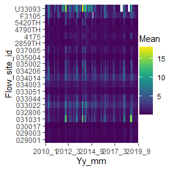

```r
# uses flow_data, as produced using import_flow()
flow_data$month <- lubridate::month(flow_data$date)
flow_data$year <- lubridate::year(flow_data$date)
temp1 <- flow_data %>%
    dplyr::group_by(month, year, flow_site_id) %>%
    dplyr::summarise(across(.cols = "flow", list(mean = ~mean(flow, na.rm = TRUE), missing = ~length(which(is.na(flow))),
        total = ~length(flow), perc_missing = ~(length(which(is.na(flow)))/length(flow)) * 100),
        .names = "{.fn}"))
temp1$yy_mm <- paste(temp1$year, temp1$month, sep = "_")

# heatmap of monthly mean flows.
a <- plot_heatmap(data = temp1, x = "yy_mm", y = "flow_site_id", fill = "mean", dual = FALSE)
# view heatmap
gridExtra::grid.arrange(a[[1]])
```

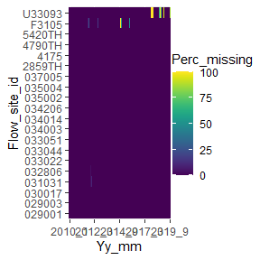

```r
# heatmap of monthly percentage completeness of the daily flow data
a <- plot_heatmap(data = temp1, x = "yy_mm", y = "flow_site_id", fill = "perc_missing")
# view heatmap
gridExtra::grid.arrange(a[[1]])
```

## Impute flow gaps

The `impute_flow` function is designed to infill missing records in daily flow time series for one or more sites (gauging stations) using either an interpolation or an equipercentile method. Imputation of missing flow data can improve the later estimation of flow statistics using the calc_flowstats() function and aid the visualisation of hydro-ecological relationships using the plot_hev() function.

Note, it is advisable to consult a hydrologist when doing any flow imputation, particularly if your data contains extensive/lengthy gaps.

The most straight-forward interpolation can be completed using a ‘linear’ or ‘exponential’ method.

The output dataset is in long format, similar to that produced by `import_flow`. The output dataset contains an ‘imputed’ colunm; this is a flag indicating whether each flow value is original (0) or imputed (1). Additionally, this function plots up observed and imputed flow values for each site; enabling the user to validate the imputation.

Flow interpolation using the ‘linear’ method is demonstated below:

```r
flow_data_imputed <- impute_flow(flow_data, site_col = "flow_site_id", date_col = "date", flow_col = "flow",
    method = "linear")
```

If applying the ‘equipercentile’ method, an optional ‘donor’ argument can be specified. The ‘donor’ argument must be specified in data frame format with at least two columns: the first a list of flow sites requiring imputation, and the second a list of paired donor sites. The function assumes that data for all flow sites specified within the ‘donor’ data table, including paired donor sites, are contained within the ‘flow_data’ supplied.

If flow data for paired donor stations are not already included within the ‘flow_data’ dataframe, then it will be necessary to appended the donor flow data, as is demonstrated below:

```r
# create 'donor' data frame
donor_mapping <- data.frame(station = ("F3105"), donor_station = ("033014"))

# get a list of donor sites
donorsites <- unique(donor_mapping$donor_station)

# download donor flow data
flow_data_donor <- import_flow(sites = donorsites, inputs = "HDE", start_date = "2010-01-01", end_date = "2019-12-31",
    dir = "data/wiski", skip_num = 21, col_order = c(1, 2, 3))
```

```
## [1] "getting flow data from: 033014"
## [1] "Using SAFE mode, downloading file first"
## # A tibble: 6 x 4
##   wiskiID date       value quality
##   <chr>   <date>     <dbl> <chr>
## 1 033014  2010-01-01  2.27 Good
## 2 033014  2010-01-02  1.52 Good
## 3 033014  2010-01-03  1.29 Good
## 4 033014  2010-01-04  1.23 Good
## 5 033014  2010-01-05  1.19 Good
## 6 033014  2010-01-06  1.14 Good
## # A tibble: 6 x 4
##   wiskiID date       value quality
##   <chr>   <date>     <dbl> <chr>
## 1 033014  2019-12-26  2.12 Good
## 2 033014  2019-12-27  1.95 Good
## 3 033014  2019-12-28  1.75 Good
## 4 033014  2019-12-29  1.6  Good
## 5 033014  2019-12-30  1.47 Good
## 6 033014  2019-12-31  1.36 Good
```

```r
# append donor flow data to the original flow data
flow_data_all <- dplyr::bind_rows(flow_data, flow_data_donor)

# impute flow data using the equipercentile method
flow_data_imputed <- impute_flow(flow_data_all, site_col = "flow_site_id", date_col = "date", flow_col = "flow",
    method = "equipercentile", donor = donor_mapping)
```

## Calculate flow statistics

`calc_flowstats` takes a time series of measured or modelled flows and uses a user-defined moving window to calculate a suite of long-term and time-varying flow statistics flow statistics for one or more sites (stations).

The function uses the win_start, win_width and win_step arguments to define a moving window, which divides the flow time series into a sequence of time periods. These time periods may be contiguous, non-contiguous or overlapping.

The sequence of time periods continues up to and including the present date, even when this extends beyond the period covered by the input flow dataset, as this facilitates the subsequent joining of flow statistics and ecology data by the `join_he` function.

It is primarily designed to work with mean daily flows (e.g. as produced by import_flow), but can also be applied to time series data on a longer (e.g. monthly) time step.

Regardless, the data should be regularly spaced and the same time step should be used for all sites.

This is an updated version of the `calc_flowstats` function. The first iteration of the function, which employs fixed 6-monthly spring and autumn flow periods, remains available using `calc_flowstats_old`.

```r
# uses flow_data, as produced using import_flow() will also accept interpolated flow data
# (flow_data_imputed), as produced using impute_flow()

# set any negative flow readings to NA
flow_data$flow[flow_data$flow <= 0] <- NA

# calculate flow statistics
flow_stats <- calc_flowstats(data = flow_data, site_col = "flow_site_id", date_col = "date", flow_col = "flow")
```

`calc_flowstats` returns a list of two data frames. The first contains a suite of time-varying flow statistics for every 6 month winter/summer period at every site. See `?calc_flowstats` for definitions of these statistics.

```r
# view time-varying flow statistics
flow_stats[[1]]
```

```
##    flow_site_id win_no start_date   end_date n_data n_missing n_total prop_missing mean sd Q5
## 1        029001      1 1995-04-01 1995-09-30      0       183     183          Inf   NA NA NA
## 2        029001      2 1995-10-01 1996-03-31      0       183     183          Inf   NA NA NA
## 3        029001      3 1996-04-01 1996-09-30      0       183     183          Inf   NA NA NA
## 4        029001      4 1996-10-01 1997-03-31      0       182     182          Inf   NA NA NA
## 5        029001      5 1997-04-01 1997-09-30      0       183     183          Inf   NA NA NA
## 6        029001      6 1997-10-01 1998-03-31      0       182     182          Inf   NA NA NA
## 7        029001      7 1998-04-01 1998-09-30      0       183     183          Inf   NA NA NA
## 8        029001      8 1998-10-01 1999-03-31      0       182     182          Inf   NA NA NA
## 9        029001      9 1999-04-01 1999-09-30      0       183     183          Inf   NA NA NA
## 10       029001     10 1999-10-01 2000-03-31      0       183     183          Inf   NA NA NA
## 11       029001     11 2000-04-01 2000-09-30      0       183     183          Inf   NA NA NA
## 12       029001     12 2000-10-01 2001-03-31      0       182     182          Inf   NA NA NA
## 13       029001     13 2001-04-01 2001-09-30      0       183     183          Inf   NA NA NA
## 14       029001     14 2001-10-01 2002-03-31      0       182     182          Inf   NA NA NA
```

[output cut: 76 more lines]

The second data table contains long-term flow statistics. The data are arranged in long format, with the following columns:

```r
# view long-term flow statistics
flow_stats[[2]]
```

```
## # A tibble: 2,600 x 5
##    flow_site_id start_date end_date   parameter  value
##    <chr>        <date>     <date>     <chr>      <dbl>
##  1 029001       2010-01-01 2019-12-31 maxsd      0.922
##  2 029003       2010-01-01 2019-12-31 maxsd      1.04
##  3 030017       2010-01-01 2019-12-31 maxsd      1.18
##  4 031031       2010-01-01 2019-12-31 maxsd     12.6
##  5 032806       2010-01-01 2019-12-31 maxsd      5.30
##  6 033022       2010-01-01 2019-12-31 maxsd      8.25
##  7 033044       2010-01-01 2019-12-31 maxsd      3.10
##  8 033051       2010-01-01 2019-12-31 maxsd      2.91
##  9 034003       2010-01-01 2019-12-31 maxsd      1.28
## 10 034014       2010-01-01 2019-12-31 maxsd      5.35
## # ... with 2,590 more rows
```

## Join biology and flow data

The `join_he` function links biology data with time-varying flow statistics for one or more antecedent (lagged) time periods (as calculated by the `calc_flowstats` function) to create a combined dataset for hydro-ecological modelling.

The function allows to user to select a method for linking biology samples to flow statistics for antecedent time periods: * using method = “A” (default), lag 0 is defined for each biology sample as the most recently finished flow time period; * using method = “B”, lag 0 is defined as the most recently started flow time period. To describe the antecedent flow conditions prior to each biology sample, the time periods are labelled relative to the date of the biology sample, with lag 0 representing either the most recently finished (method = “A”) or most recently started (method = “B”) flow time period. The time period immediately prior to the Lag 0 time period is the Lag 1 period, and the period immediately prior to that is the Lag 2 period, and so on. The function allows the user to select which antecedent (lagged) time periods the biology data is joined to, e.g. lag = c(0,1,2). This method is demonstrated in the schematic below.

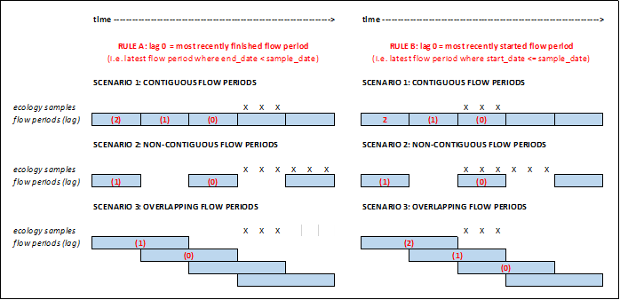

The function also includes an option to specify the ‘join_type’: * “add_flows” (default) produces a dataset of biological metrics (response variables) and flow statistics (predictor variables) for hydro-ecological modelling. * “add_biol” produces a time series of flow statistics with associated biological metrics which can be used to assess the coverage of historical flow conditions using the `plot_rngflows` function.

This is an updated version of the `join_he` function. The first iteration of the function remains available, using `join_he_old`.

We will join the data for the pairs of biology and flow sites specified in `master_data`.

```r
# get output from calc_flowstats
flowstats_1 <- flow_stats[[1]]

# create two-column table mapping biology sites to flow sites
mapping <- master_data[, c("biol_site_id", "flow_site_id")]

# join flow statistics to biology data

join_data <- join_he(biol_data = biol_all, flow_stats = flowstats_1, mapping = mapping, lags = c(0,
    1), method = "A", join_type = "add_flows")

# view join_data
join_data
```

```
## # A tibble: 488 x 177
##    biol_site_id  Year Season WHPT_ASPT WHPT_NTAXA PSI_F LIFE_F date       TL2_WHPT_NTAXA_AbW_Di~
##    <chr>        <dbl> <chr>      <dbl>      <dbl> <dbl>  <dbl> <date>                      <dbl>
##  1 34310         2010 Autumn      5.98         18  67.6   8.06 2010-09-13                   27.9
##  2 34310         2010 Spring      5.75         27  56.2   7.25 2010-04-21                   27.3
##  3 34310         2010 Summer      5.65         22  56.4   7.21 2010-07-06                   29.6
##  4 34310         2011 Autumn      5.75         29  60.4   7.44 2011-10-24                   27.9
##  5 34310         2011 Spring      5.99         27  66     7.61 2011-03-07                   27.3
##  6 34310         2011 Summer      5.87         22  65.8   7.55 2011-07-11                   29.6
##  7 34310         2012 Autumn      5.09         27  45.8   7.08 2012-09-12                   27.9
##  8 34310         2012 Spring      5.78         30  59.6   7.28 2012-04-12                   27.3
##  9 34310         2012 Summer      5.85         32  58.9   7.28 2012-07-25                   29.6
## 10 34310         2013 Autumn      5.7          28  59.3   7.5  2013-10-17                   27.9
## # ... with 478 more rows, and 168 more variables: TL2_WHPT_ASPT_AbW_DistFam <dbl>,
## #   TL3_LIFE_Fam_DistFam <dbl>, TL3_PSI_Fam <dbl>, WATER_BODY <chr>, NGR_PREFIX <chr>,
## #   EASTING <chr>, NORTHING <chr>, WFD_WATERBODY_ID <chr>, ALTITUDE <dbl>, SLOPE <dbl>,
## #   DIST_FROM_SOURCE <dbl>, DISCHARGE <dbl>, WIDTH <dbl>, DEPTH <dbl>, BOULDERS_COBBLES <dbl>,
## #   PEBBLES_GRAVEL <dbl>, SAND <dbl>, SILT_CLAY <dbl>, ALKALINITY <dbl>, CONDUCTIVITY <dbl>,
## #   TOTAL_HARDNESS <dbl>, CALCIUM <dbl>, WHPT_ASPT_O <dbl>, WHPT_ASPT_E <dbl>,
## #   WHPT_ASPT_OE <dbl>, WHPT_NTAXA_O <dbl>, WHPT_NTAXA_E <dbl>, WHPT_NTAXA_OE <dbl>, ...
```

## Join RHS data

If required, the RHS data can also be joined manually to the combined biology and flow dataset.

```r
# create mapping rhs_survey_id <- as.character(rhssurveys) flow_site_id <-
# as.character(flowsites) mapping <- data.frame(flow_site_id, rhs_survey_id)

# create two-column table mapping biology sites to RHS surveys
mapping <- master_data[, c("biol_site_id", "rhs_survey_id")]

# Join RHS data to join_data
all_data <- dplyr::left_join(join_data, mapping, by = "biol_site_id")
all_data <- dplyr::left_join(all_data, rhs_data, by = "rhs_survey_id")
```

# Exploratory data anlaysis

## Pairwise correlations

Plotting pairwise correlations among alternative biological metrics can be useful when deciding which metric(s) to analysis. In this example, the `ggpairs` function from the `GGally` package is used to explore the distribution and correlations of four commonly used macroinvertebrate metrics.

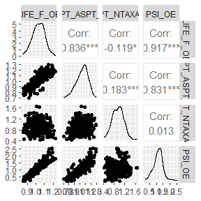

```r
GGally::ggpairs(all_data, columns=c("LIFE_F_OE", "WHPT_ASPT_OE", "WHPT_NTAXA_OE", "PSI_OE"),
                         upper = list(continuous = GGally::wrap("cor")),
                         diag = list(continuous = "densityDiag"),
                         lower = list(continuous = GGally::wrap("points")))
```

Similarly, a `ggpairs` plot can also be used to visualise relationships between response and predictor variables, and to identify co-linearity among predictor variables.

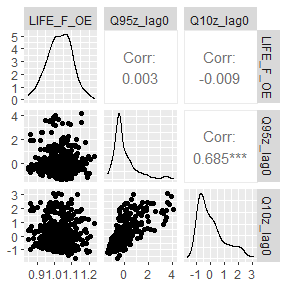

```r
GGally::ggpairs(all_data, columns=c("LIFE_F_OE", "Q95z_lag0", "Q10z_lag0"),
                         upper = list(continuous = GGally::wrap("cor")),
                         diag = list(continuous = "densityDiag"),
                         lower = list(continuous = GGally::wrap("points")))
```

## Assess site similarity

Prior to building a hydro-ecological model, it is important identify any sites that could potentially be outliers because they are physically, chemically or geographically dissimilar to the others sites in the dataset. The `plot-sitepca` function performs a Principal Components Analysis (PCA) which reduces a set of site-level environmental variables down to two uncorrelated ‘principal components’ and plots these components as a two-dimensional scatter plot. Sites that are closer together have more similar environmental characteristics. The proportion of the total environmental variation explained by each component is indicated on the axis labels. The environmental gradients represented by the two axes can be interpreted by reference to the arrows (eigenvectors), which show the direction and strength of correlation between the principal components and the individual environmental variables.

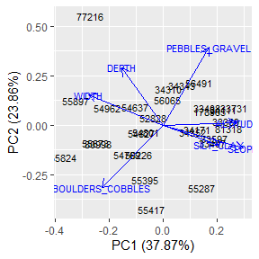

```r
plot_sitepca(data = env_data, vars = c("ALTITUDE", "SLOPE", "WIDTH", "DEPTH", "BOULDERS_COBBLES", "PEBBLES_GRAVEL", "SILT_CLAY"), eigenvectors = TRUE, label_by = "biol_site_id")
```

In this example, the first component (x-axis) can be interpreted as a longitudinal gradient from wider, deeper rivers (left) to smaller, steeper streams (right), and the second component (y-axis) can be interpreted a gradient in substrate composition from finer pebbles/gravels (top) to coarser boulder/cobbles (bottom). On the basis of these results, we may wish to consider whether sites such as 77216 and 55824 are suitable for inclusion in the model, or whether they are sufficiently different to warrant being excluded.

## Assess coverage of historical flow conditions

A hydro-ecological model has a greater chance of revealing relationships between biology metrics and flow variables if the biology samples span a wide range of flow conditions. Good coverage of historical flow conditions by the biology sample data also means that the calibrated model is likely to be better at predicting biological responses under high and low flow scenarios.

The `plot_rngflows` function generates a scatterplot for two flow variables and overlays two convex hulls: one showing the full range of flow conditions experienced historically, and a second convex hull showing the range of flow conditions with associated biology samples. This visualisation helps identify to what extent the available biology data span the full range of full range of flow conditions experienced historically.

In the following example, the Q95z and Q10z flow statistics have been selected as measures of low and high flows within each six month period. The first plot shows the data for all 20 sites; the second plot is faceted to show the data separately for each site individually. In this dataset, biology samples are present for almost every six month period, and so provide excellent coverage of historical flow conditions.

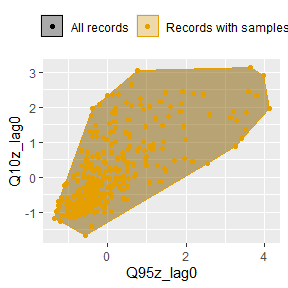

```r
plot_rngflows(data = all_data, flow_stats = c("Q95z_lag0", "Q10z_lag0"), biol_metric = "LIFE_F_OE", wrap_by = NULL, label = "Year")
```

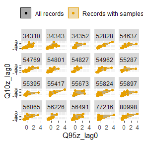

```r
plot_rngflows(data = all_data, flow_stats = c("Q95z_lag0", "Q10z_lag0"), biol_metric = "LIFE_F_OE", wrap_by = "biol_site_id", label = "Year")
```

## HEV plots

The `plot_hev` function generates, for one site of interest, a time series plot of biology sample data and flow summary statistics, often referred to by the EA as a hydro-ecological validation (HEV) plot. HEV plots provide a visual assessment of trends in the historical data, and an initial guide to possible relationships that could be explored and quantified within a hydro-ecological model.

Whilst the dataset outputted by the `join_he` function can be used to produce a HEV plot, a better solution is achieved by via a combination of manual processing and the `add biol` functionality of `join_he`.

```r
# get output from calc_flowstats
flowstats_1 <- flow_stats[[1]]

# create two-column table mapping biology sites to flow sites
mapping <- data.frame(master_data[, c("biol_site_id", "flow_site_id")])

# filter biology and flow datasets to sites of interest
biol_data_hev <- dplyr::filter(biol_all, biol_site_id %in% unique(mapping$biol_site_id))
flow_data_hev <- dplyr::filter(flowstats_1, flow_site_id %in% unique(mapping$flow_site_id))

# create a complete daily time series for each biology site
hev_data <- expand.grid(
  biol_site_id = unique(biol_data_hev$biol_site_id),
  date = seq.Date(as.Date("2011-01-01"), as.Date("2019-12-31"), by="day"),
  stringsAsFactors = FALSE)

# create season and water_year columns on which to join the six-monthly flow statistics
hev_data$Month <- lubridate::month(hev_data$date)
hev_data$Year <- lubridate::year(hev_data$date)

# join biology and flow data
hev_data <- hev_data %>%
  left_join(biol_data_hev, by = c("biol_site_id", "date", "Year"))

hev_data <- join_he(biol_data = hev_data, flow_stats = flow_data_hev, mapping = mapping, method = "A", join_type = "add_biol")
```

Using this new `hev_data` dataset, the following example uses `multiplot = TRUE` to produce HEV plots for four macroinvertebrate metrics at one site.

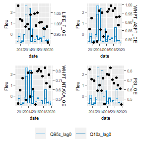

```r
plot_hev(data = subset(hev_data, biol_site_id == "34352"),
         date_col = "date",
         flow_stat = c("Q95z_lag0", "Q10z_lag0"),
         biol_metric = c("LIFE_F_OE", "WHPT_ASPT_OE", "WHPT_NTAXA_OE", "PSI_OE"),
         multiplot = TRUE)
```

The `save` argument can be used to export the HEV plot as a .png file. The name of the png file is fixed, however, so to generate a separate png file for each site requires a loop.

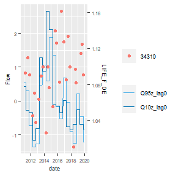

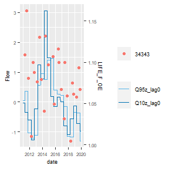

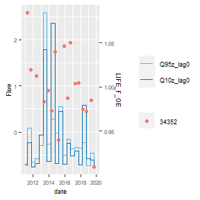

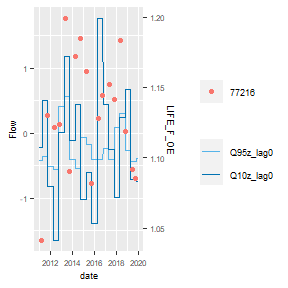

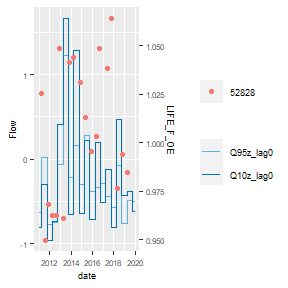

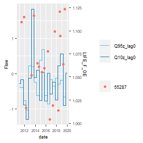

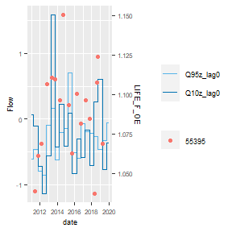

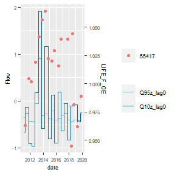

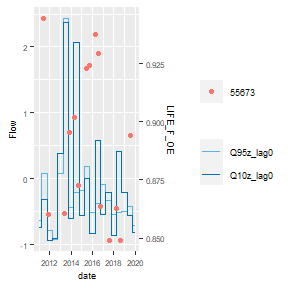

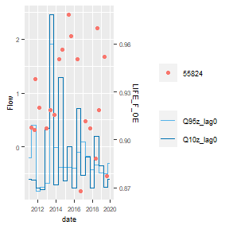

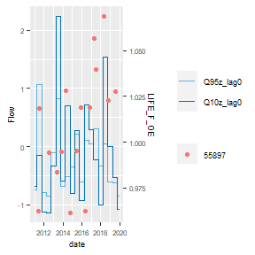

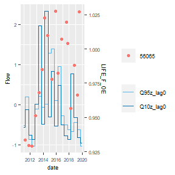

[8 more figures not shown]

```r
for(i in mapping$biol_site_id){

  plot_data <- subset(hev_data, biol_site_id == i)

  my_hev_plot <- plot_hev(data = plot_data,
         date_col = "date",
         flow_stat = c("Q95z_lag0", "Q10z_lag0"),
         biol_metric = c("LIFE_F_OE"),
         clr_by = "biol_site_id")

  ggsave(plot = my_hev_plot, device = "png", filename = paste0(biolsites[i],"_hevplot.png"))

}
```

To interactively examine time series relationships for different metrics and sites, use the `shiny_hev` function, which launches a HEV plot within a shiny app.